# Cooperation in innovation

luismor

3/25/2021

```r
#Carga de datos
library(readxl)
library(dplyr)
df <- read_excel("/Users/unimooc/Dropbox/2021/Directorio R/Research/Cooperation/DATOS 2004-2014.xlsx", sheet = "2004-2014")
head(df)
```

```
## # A tibble: 6 x 41
##   IDENT ACTIVIDAD PERIODO INTEC INTECMAN  CIFRA  GTINN  INTINN TAMANO MDOLOCAL
##   <dbl>     <dbl> <chr>   <dbl> <chr>     <dbl>  <dbl>   <dbl>  <dbl>    <dbl>
## 1     1        15 2004-2…     2 2.4      7.81e6  14232 0.00182     49        1
## 2     2        17 2004-2…     2 2.4      3.19e7 291379 0.00913    212        1
## 3     3        19 2004-2…     2 2.4      4.52e6 177232 0.0392      49        1
## 4     4        18 2004-2…     2 2.4      1.33e7 172760 0.0130      96        1
## 5     5        33 2004-2…     2 2.1      2.82e8 320506 0.00114   1129        1
## 6     6        34 2004-2…     2 2.2      1.42e8 713878 0.00504    319        1
## # … with 31 more variables: MDONAC <dbl>, MDOUE <dbl>, INNPROD <dbl>,
## #   INNOBIEN <dbl>, INNOSERV <dbl>, INNPROC <dbl>, INNFABRI <dbl>,
## #   INNLOGIS <dbl>, INNAPOYO <dbl>, COOP <dbl>, GIO1 <dbl>, GIO2 <dbl>,
## #   GIO3 <dbl>, GIO4 <dbl>, GIO5 <dbl>, GIO6 <dbl>, GIO7 <dbl>, GIO8 <dbl>,
## #   GIO9 <dbl>, F1 <dbl>, F2 <dbl>, F3 <dbl>, F4 <dbl>, F5 <dbl>, F6 <dbl>,
## #   F7 <dbl>, F8 <dbl>, F9 <dbl>, F10 <dbl>, F11 <dbl>, TIEMPO <dbl>
```

```r
df <- na.omit(df)
anyNA(df)
```

```
## [1] FALSE
```

```r
df.gr <- filter(df, TIEMPO <= 2007)
df.cr <- filter(df, TIEMPO %in% c(2008, 2009, 2010))
df.re <- filter(df, TIEMPO >= 2011)
```

## Chi Cuadrado

Creamos un dataframe con las variables COOP y Tiempo.

```r
df.or <- df[,c("COOP","TIEMPO")]
```

Creamos variables categóricas con la inormación de “TIEMPO” y “COOP”

```r
facTiemp <- factor(df$TIEMPO,
                 levels = c(2004,2005,2006,2007,
                            2008,2009,2010
                            ,2011, 2012, 2013, 2014),
                 labels = c("Growth", "Growth", "Growth", "Growth",
                            "Crisis", "Crisis", "Crisis",
                            "Recovery", "Recovery", "Recovery", "Recovery"))
df$facTiemp <- facTiemp

facCoop <- factor(df$COOP,
                 levels = c(0, 1),
                 labels = c("NoCoop", "Coop"))

df$facCoop <- facCoop
```

Creamos variables dicotómicas en función de los distintos momentos del periodo económico

```r
#Etapa de crecimiento
df$facTiempG <- factor(df$TIEMPO,
                   levels = c(2004,2005,2006,2007,
                              2008,2009,2010
                              ,2011, 2012, 2013, 2014),
                   labels = c("1", "1", "1", "1",
                              "0", "0", "0",
                              "0", "0", "0", "0"))

#Etapa de crisis
df$facTiempC <- factor(df$TIEMPO,
                    levels = c(2004,2005,2006,2007,
                               2008,2009,2010
                               ,2011, 2012, 2013, 2014),
                    labels = c("0", "0", "0", "0",
                               "1", "1", "1",
                               "0", "0", "0", "0"))

#Etapa de recuperación
df$facTiempR <- factor(df$TIEMPO,
                    levels = c(2004,2005,2006,2007,
                               2008,2009,2010
                               ,2011, 2012, 2013, 2014),
                    labels = c("0", "0", "0", "0",
                               "0", "0", "0",
                               "1", "1", "1", "1"))
```

#Chi cuadrado - Pearson para la primera hipótesis

H1: Companies change their perspective on cooperation to develop innovation according to the economic cycle.

```r
tablaCoop <-table(df$facCoop, df$facTiemp)
chisq.test(tablaCoop,correct=FALSE)
```

```
##
##  Pearson's Chi-squared test
##
## data:  tablaCoop
## X-squared = 620.47, df = 2, p-value < 2.2e-16
```

```r
tablaCoopG <-table(df$facCoop, df$facTiempG)
chisq.test(tablaCoopG, correct=FALSE)
```

```
##
##  Pearson's Chi-squared test
##
## data:  tablaCoopG
## X-squared = 339.69, df = 1, p-value < 2.2e-16
```

```r
tablaCoopC <-table(df$facCoop, df$facTiempC)
chisq.test(tablaCoopC, correct=FALSE)
```

```
##
##  Pearson's Chi-squared test
##
## data:  tablaCoopC
## X-squared = 13.291, df = 1, p-value = 0.0002667
```

```r
tablaCoopR <-table(df$facCoop, df$facTiempR)
chisq.test(tablaCoopR, correct=FALSE)
```

```
##
##  Pearson's Chi-squared test
##
## data:  tablaCoopR
## X-squared = 577.95, df = 1, p-value < 2.2e-16
```

Cálculo de medias

```r
  mean(df$COOP)
```

```
## [1] 0.1508814
```

```r
  mean(df.gr$COOP)
```

```
## [1] 0.1242933
```

```r
  mean(df.cr$COOP)
```

```
## [1] 0.143812
```

```r
  mean(df.re$COOP)
```

```
## [1] 0.199162
```

Representación gráfica

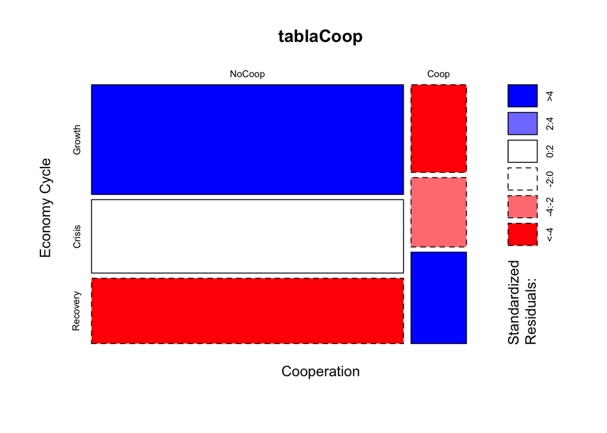

```r
mosaicplot(tablaCoop, ylab="Economy Cycle", xlab = "Cooperation",
           shade = T)
```

#Chi cuadrado - Pearson para la segunda hipótesis H2: Companies change their views on the competitive need for innovation depending on the economic cycle.

```r
    DOI_1 <-table(df$GIO1, df$facTiemp)
    chisq.test(DOI_1,correct=FALSE)
```

```
##
##  Pearson's Chi-squared test
##
## data:  DOI_1
## X-squared = 723.59, df = 6, p-value < 2.2e-16
```

```r
    DOI_2 <-table(df$GIO2, df$facTiemp)
    chisq.test(DOI_2,correct=FALSE)
```

```
##
##  Pearson's Chi-squared test
##
## data:  DOI_2
## X-squared = 1281.2, df = 6, p-value < 2.2e-16
```

```r
    DOI_3 <-table(df$GIO3, df$facTiemp)
    chisq.test(DOI_3,correct=FALSE)
```

```
##
##  Pearson's Chi-squared test
##
## data:  DOI_3
## X-squared = 905.93, df = 6, p-value < 2.2e-16
```

```r
    DOI_4 <-table(df$GIO4, df$facTiemp)
    chisq.test(DOI_4,correct=FALSE)
```

```
##
##  Pearson's Chi-squared test
##
## data:  DOI_4
## X-squared = 645.66, df = 6, p-value < 2.2e-16
```

```r
    DOI_5 <-table(df$GIO5, df$facTiemp)
    chisq.test(DOI_5,correct=FALSE)
```

```
##
##  Pearson's Chi-squared test
##
## data:  DOI_5
## X-squared = 371.83, df = 6, p-value < 2.2e-16
```

```r
    DOI_6 <-table(df$GIO6, df$facTiemp)
    chisq.test(DOI_6,correct=FALSE)
```

```
##
##  Pearson's Chi-squared test
##
## data:  DOI_6
## X-squared = 1607.7, df = 6, p-value < 2.2e-16
```

```r
    DOI_7 <-table(df$GIO7, df$facTiemp)
    chisq.test(DOI_7,correct=FALSE)
```

```
##
##  Pearson's Chi-squared test
##
## data:  DOI_7
## X-squared = 7763.1, df = 6, p-value < 2.2e-16
```

```r
    DOI_8 <-table(df$GIO8, df$facTiemp)
    chisq.test(DOI_8,correct=FALSE)
```

```
##
##  Pearson's Chi-squared test
##
## data:  DOI_8
## X-squared = 748.2, df = 6, p-value < 2.2e-16
```

```r
    DOI_9 <-table(df$GIO9, df$facTiemp)
    chisq.test(DOI_9,correct=FALSE)
```

```
##
##  Pearson's Chi-squared test
##
## data:  DOI_9
## X-squared = 201.83, df = 6, p-value < 2.2e-16
```

```r
    #Replicar para facTiempG, facTiempC, facTiempR
```

Cálculo de medias

```r
  mean(df$GIO1)
```

```
## [1] 2.090599
```

```r
  mean(df$GIO2)
```

```
## [1] 2.287346
```

```r
  mean(df$GIO3)
```

```
## [1] 1.968636
```

```r
  mean(df.gr$GIO1)
```

```
## [1] 2.160374
```